# **Analyzing Kobe Bryant’s Career Shot Selection**

## Dylan Kilgour & Grace Dickman

```r
library(ggplot2)
library(MASS)
library(caret)
```

### **Introduction**

The data set we chose from Kaggle contains every shot from Kobe Bryant’s NBA career accompanied by statistics that give various descriptions about the shot, i.e. location, make, miss, game situation. Using the statistics provided, we will attempt to build a model that will be able to predict a made or missed shot given certain parameters. The data set we are using contains over 30,000 data points so our model has the potential to be extremely accurate. Some of the variables we will look at will be `action-type`, `combined-shot-type`, `lat`, `loc_x`, `loc_y`, `minutes_remaining`, `seconds_remaining` and `shot_zone_area`. We will start with these to create a simple model and if able, we can make a more complex model where shots can be affected by the specific opponent and if the shot is taken in the playoffs.

First we can make a simple shot chart of all of Kobe’s makes and misses in his career. A value of 1 indicates a made shot, where a value of 0 indicates a missed shot.

```r
# Court
kobedata <- read.csv("~/DylanProject/kobedata.csv")
kobedata_v2 <- kobedata[complete.cases(kobedata),]
kobedata_v2$made_or_missed <- factor(kobedata_v2$shot_made_flag)
require(RCurl)
```

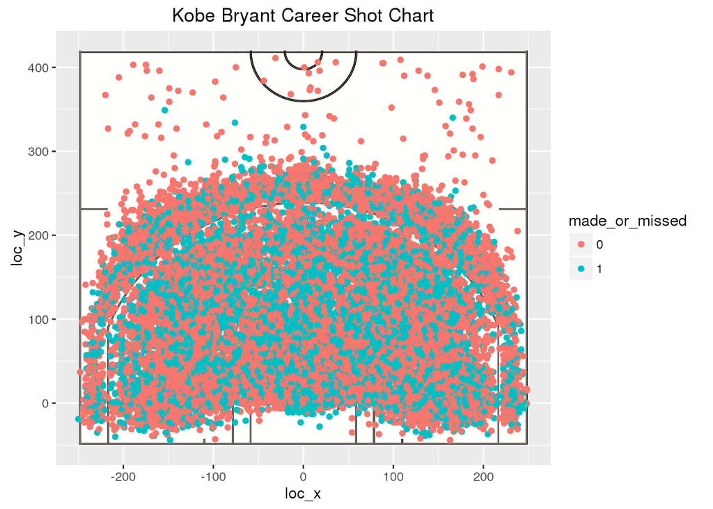

```r
library(grid)
library(jpeg)

# half court image
courtImg.URL <- "https://thedatagame.files.wordpress.com/2016/03/nba_court.jpg"
court <- rasterGrob(readJPEG(getURLContent(courtImg.URL)),
           width=unit(1,"npc"), height=unit(1,"npc"))


ggplot(kobedata_v2, aes(x=loc_x, y=loc_y)) +
  annotation_custom(court, -250, 250, -50, 420) + geom_point(aes(colour = made_or_missed)) + xlim(-250,250) + ylim(-50,420) + ggtitle(paste("Kobe Bryant Career Shot Chart"))
```

To see a smaller sample, we can look at a random sample of 1000 shots.

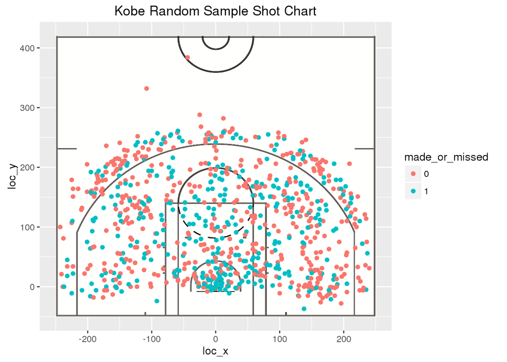

```r
kobesamp_v2 <- kobedata_v2[sample(1:nrow(kobedata_v2), 1000,
    replace=FALSE),]

ggplot(kobesamp_v2, aes(x=loc_x, y=loc_y)) +
  annotation_custom(court, -250, 250, -50, 420) + geom_point(aes(colour = made_or_missed)) + xlim(-250,250) + ylim(-50,420) + ggtitle(paste("Kobe Random Sample Shot Chart"))
```

### **Finding Relationships between Variables**

#### Simple Linear Models

Before we can build the model, we must look at which variables have an impact on which shots Kobe sinks. We can begin by constructing simple linear models.

```r
mod1 <- lm(shot_made_flag ~ combined_shot_type, data = kobedata_v2)
summary(mod1)
```

```
##
## Call:
## lm(formula = shot_made_flag ~ combined_shot_type, data = kobedata_v2)
##
## Residuals:
##     Min      1Q  Median      3Q     Max
## -0.9280 -0.3911 -0.3911  0.6089  0.6513
##
## Coefficients:
##                             Estimate Std. Error t value Pr(>|t|)
## (Intercept)                  0.79167    0.04398  17.999  < 2e-16 ***
## combined_shot_typeDunk       0.13636    0.04641   2.938  0.00331 **
## combined_shot_typeHook Shot -0.25623    0.06134  -4.177 2.96e-05 ***
## combined_shot_typeJump Shot -0.40060    0.04412  -9.080  < 2e-16 ***
## combined_shot_typeLayup     -0.22657    0.04456  -5.085 3.71e-07 ***
## combined_shot_typeTip Shot  -0.44298    0.05884  -7.529 5.28e-14 ***
## ---
## Signif. codes:  0 '***' 0.001 '**' 0.01 '*' 0.05 '.' 0.1 ' ' 1
##
## Residual standard error: 0.4818 on 25691 degrees of freedom
## Multiple R-squared:  0.06077,    Adjusted R-squared:  0.06059
## F-statistic: 332.5 on 5 and 25691 DF,  p-value: < 2.2e-16
```

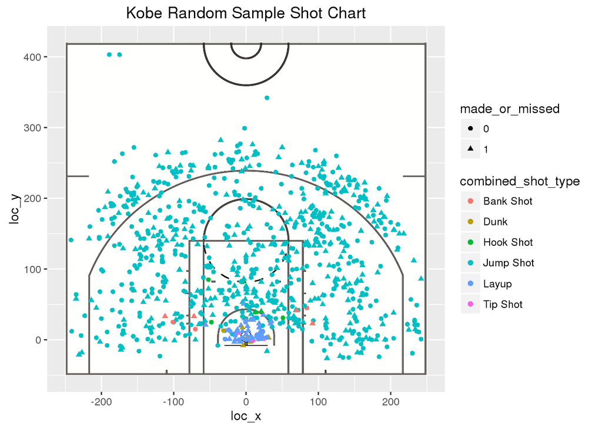

```r
kobesamp_v2 <- kobedata_v2[sample(1:nrow(kobedata_v2), 1000,
    replace=FALSE),]

ggplot(kobesamp_v2, aes(x=loc_x, y=loc_y)) +
  annotation_custom(court, -250, 250, -50, 420) + geom_point(aes(colour = combined_shot_type, shape=made_or_missed)) + xlim(-250,250) + ylim(-50,420) + ggtitle(paste("Kobe Random Sample Shot Chart"))
```

An interpretation of this linear model is that dunks are Kobe’s most effective shot, and his makes decrease for all other shot types. Tip-shots are his least effective shot as this model shows. The random sample shot chart is adjusted to account for the shot types and whether Kobe made or missed. This gives a good visual representation of the categories of our data and of the number of these respective shots Kobe was taking throughout his career.

```r
mod2 <- lm(shot_made_flag ~ loc_x + loc_y, data = kobedata_v2)
summary(mod2)
```

```
##
## Call:
## lm(formula = shot_made_flag ~ loc_x + loc_y, data = kobedata_v2)
##
## Residuals:
##     Min      1Q  Median      3Q     Max
## -0.5599 -0.4601 -0.3333  0.5029  0.8387
##
## Coefficients:
##               Estimate Std. Error t value Pr(>|t|)
## (Intercept)  5.225e-01  4.422e-03 118.166   <2e-16 ***
## loc_x       -1.559e-05  2.787e-05  -0.559    0.576
## loc_y       -8.353e-04  3.480e-05 -24.006   <2e-16 ***
## ---
## Signif. codes:  0 '***' 0.001 '**' 0.01 '*' 0.05 '.' 0.1 ' ' 1
##
## Residual standard error: 0.4916 on 25694 degrees of freedom
## Multiple R-squared:  0.02194,    Adjusted R-squared:  0.02186
## F-statistic: 288.1 on 2 and 25694 DF,  p-value: < 2.2e-16
```

This model gives an intuitive result that Kobe’s made shots decrease the farther away from the basket he is.

#### Logistial Regression Models

Now we will look at a logistical regression model because our outcome variable is binary. We can start with `shot_made_flag` based on `loc_x` and `loc_y`.

```r
glmmod1 <- glm(shot_made_flag ~ loc_x + loc_y,data=kobedata_v2,family=binomial())
summary(glmmod1)
```

```
##
## Call:
## glm(formula = shot_made_flag ~ loc_x + loc_y, family = binomial(),
##     data = kobedata_v2)
##
## Deviance Residuals:
##     Min       1Q   Median       3Q      Max
## -1.2881  -1.1085  -0.8984   1.1810   1.8108
##
## Coefficients:
##               Estimate Std. Error z value Pr(>|z|)
## (Intercept)  0.0988374  0.0182296   5.422  5.9e-08 ***
## loc_x       -0.0000642  0.0001155  -0.556    0.578
## loc_y       -0.0035213  0.0001498 -23.508  < 2e-16 ***
## ---
## Signif. codes:  0 '***' 0.001 '**' 0.01 '*' 0.05 '.' 0.1 ' ' 1
##
## (Dispersion parameter for binomial family taken to be 1)
##
##     Null deviance: 35325  on 25696  degrees of freedom
## Residual deviance: 34748  on 25694  degrees of freedom
## AIC: 34754
##
## Number of Fisher Scoring iterations: 4
```

We see similar results from the linear model previously made — Kobe’s shots go in less the further he is from the basket.

If we want to see how Kobe performs throughout the game, we can look at `minutes_remaining` and how it affects `shot_made_flag`.

```r
glmmod2 <- glm(shot_made_flag ~ minutes_remaining, data = kobedata_v2, family = binomial())
summary(glmmod2)
```

```
##
## Call:
## glm(formula = shot_made_flag ~ minutes_remaining, family = binomial(),
##     data = kobedata_v2)
##
## Deviance Residuals:
##    Min      1Q  Median      3Q     Max
## -1.129  -1.088  -1.054   1.270   1.306
##
## Coefficients:
##                    Estimate Std. Error z value Pr(>|z|)
## (Intercept)       -0.297061   0.021815 -13.617  < 2e-16 ***
## minutes_remaining  0.016513   0.003635   4.542 5.57e-06 ***
## ---
## Signif. codes:  0 '***' 0.001 '**' 0.01 '*' 0.05 '.' 0.1 ' ' 1
##
## (Dispersion parameter for binomial family taken to be 1)
##
##     Null deviance: 35325  on 25696  degrees of freedom
## Residual deviance: 35304  on 25695  degrees of freedom
## AIC: 35308
##
## Number of Fisher Scoring iterations: 3
```

This simple model tells us that the more time left in the quarter, the more Kobe makes his shots.

We’d like to see if a logistical regression model will be more accurate when looking at `combined_shot_type` and its affect on `shot_made_flag`.

```r
glmmod3 <- glm(shot_made_flag ~ combined_shot_type, data = kobedata_v2, family = binomial())
summary(glmmod3)
```

```
##
## Call:
## glm(formula = shot_made_flag ~ combined_shot_type, family = binomial(),
##     data = kobedata_v2)
##
## Deviance Residuals:
##    Min      1Q  Median      3Q     Max
## -2.294  -0.996  -0.996   1.370   1.452
##
## Coefficients:
##                             Estimate Std. Error z value Pr(>|z|)
## (Intercept)                   1.3350     0.2248   5.939 2.87e-09 ***
## combined_shot_typeDunk        1.2218     0.2544   4.803 1.56e-06 ***
## combined_shot_typeHook Shot  -1.1930     0.2867  -4.162 3.16e-05 ***
## combined_shot_typeJump Shot  -1.7778     0.2253  -7.892 2.96e-15 ***
## combined_shot_typeLayup      -1.0731     0.2268  -4.732 2.22e-06 ***
## combined_shot_typeTip Shot   -1.9598     0.2819  -6.951 3.63e-12 ***
## ---
## Signif. codes:  0 '***' 0.001 '**' 0.01 '*' 0.05 '.' 0.1 ' ' 1
##
## (Dispersion parameter for binomial family taken to be 1)
##
##     Null deviance: 35325  on 25696  degrees of freedom
## Residual deviance: 33628  on 25691  degrees of freedom
## AIC: 33640
##
## Number of Fisher Scoring iterations: 5
```

#### Adding Interaction Terms

Our models have yet to include interaction terms. Now we can see if we can improve these simple relationships by adding in interaction. First we will look at an interaction between `combined_shot_type` and `minutes_remaining`.

```r
glmint1 <- glm(shot_made_flag ~ combined_shot_type + minutes_remaining + combined_shot_type*minutes_remaining, data = kobedata_v2, family = binomial())
summary(glmint1)
```

```
##
## Call:
## glm(formula = shot_made_flag ~ combined_shot_type + minutes_remaining +
##     combined_shot_type * minutes_remaining, family = binomial(),
##     data = kobedata_v2)
##
## Deviance Residuals:
##     Min       1Q   Median       3Q      Max
## -2.3849  -1.0043  -0.9592   1.3354   1.6196
##
## Coefficients:
##                                               Estimate Std. Error z value
## (Intercept)                                    1.13443    0.39796   2.851
## combined_shot_typeDunk                         1.64949    0.45495   3.626
## combined_shot_typeHook Shot                   -0.59344    0.52296  -1.135
## combined_shot_typeJump Shot                   -1.67216    0.39877  -4.193
## combined_shot_typeLayup                       -0.97346    0.40142  -2.425
## combined_shot_typeTip Shot                    -1.50573    0.48100  -3.130
## minutes_remaining                              0.04275    0.07187   0.595
## combined_shot_typeDunk:minutes_remaining      -0.08776    0.08005  -1.096
## combined_shot_typeHook Shot:minutes_remaining -0.11853    0.09014  -1.315
## combined_shot_typeJump Shot:minutes_remaining -0.02345    0.07200  -0.326
## combined_shot_typeLayup:minutes_remaining     -0.02203    0.07242  -0.304
## combined_shot_typeTip Shot:minutes_remaining  -0.09969    0.08655  -1.152
##                                               Pr(>|z|)
## (Intercept)                                   0.004364 **
## combined_shot_typeDunk                        0.000288 ***
## combined_shot_typeHook Shot                   0.256476
## combined_shot_typeJump Shot                   2.75e-05 ***
## combined_shot_typeLayup                       0.015308 *
## combined_shot_typeTip Shot                    0.001746 **
## minutes_remaining                             0.551940
## combined_shot_typeDunk:minutes_remaining      0.272911
## combined_shot_typeHook Shot:minutes_remaining 0.188512
## combined_shot_typeJump Shot:minutes_remaining 0.744648
## combined_shot_typeLayup:minutes_remaining     0.760935
## combined_shot_typeTip Shot:minutes_remaining  0.249379
## ---
## Signif. codes:  0 '***' 0.001 '**' 0.01 '*' 0.05 '.' 0.1 ' ' 1
##
## (Dispersion parameter for binomial family taken to be 1)
##
##     Null deviance: 35325  on 25696  degrees of freedom
## Residual deviance: 33596  on 25685  degrees of freedom
## AIC: 33620
##
## Number of Fisher Scoring iterations: 5
```

Shot types seem to be affected by the minutes remaining in the game, but none of the results are statistically significant. Therefore, we cannot consider these results to be useful.

## **LDA and QDA**

```r
sample_size <- floor(0.75 * nrow(kobedata_v2))

## setting the seed
set.seed(123)
train_ind <- sample(seq_len(nrow(kobedata_v2)), size = sample_size)

train1 <- kobedata_v2[train_ind, ]
test1 <- kobedata_v2[-train_ind, ]

# LDA
mod_LDA_one <- lda(shot_made_flag ~ minutes_remaining + seconds_remaining + season + shot_distance + game_id + opponent + shot_type, data = train1)
mod_LDA_one
```

```
## Call:
## lda(shot_made_flag ~ minutes_remaining + seconds_remaining +
##     season + shot_distance + game_id + opponent + shot_type,
##     data = train1)
##
## Prior probabilities of groups:
##         0         1
## 0.5557804 0.4442196
##
## Group means:
##   minutes_remaining seconds_remaining season1997-98 season1998-99
## 0          4.779666          27.69844    0.03183643    0.02940902
## 1          5.018573          29.13094    0.03025348    0.02896858
##   season1999-00 season2000-01 season2001-02 season2002-03 season2003-04
## 0    0.04966857    0.05872468    0.06600691     0.0741294    0.05284287
## 1    0.05548417    0.06611377    0.06552973     0.0691508    0.05396566
##   season2004-05 season2005-06 season2006-07 season2007-08 season2008-09
## 0    0.04509383    0.07347587    0.05965830    0.06834096    0.06880777
## 1    0.04497138    0.07604252    0.06412802    0.07452400    0.07137017
##   season2009-10 season2010-11 season2011-12 season2012-13 season2013-14
## 0    0.06834096    0.05835123    0.05713752    0.04920176   0.002614135
## 1    0.07300549    0.06097419    0.05162948    0.05209672   0.001985749
##   season2014-15 season2015-16 shot_distance  game_id opponentBKN
## 0    0.02651480    0.04350668      15.12651 24722337 0.001867239
## 1    0.01775494    0.02885177      11.31912 24684408 0.001518514
##   opponentBOS opponentCHA opponentCHI opponentCLE opponentDAL opponentDEN
## 0  0.03389039  0.02072636  0.02175334  0.01923256  0.03949211  0.05088227
## 1  0.02850134  0.01892302  0.01962388  0.01903983  0.04111669  0.05291438
##   opponentDET opponentGSW opponentHOU opponentIND opponentLAC opponentMEM
## 0  0.02371394  0.04425357  0.05368313  0.02604799  0.04238633  0.03482401
## 1  0.02254410  0.04789160  0.05361523  0.02219367  0.04146712  0.03305689
##   opponentMIA opponentMIL opponentMIN opponentNJN opponentNOH opponentNOP
## 0  0.02007282  0.02119317  0.04490710  0.01652507  0.01839231  0.01269723
## 1  0.01892302  0.01857260  0.04555543  0.01448429  0.01939026  0.01016236
##   opponentNYK opponentOKC opponentORL opponentPHI opponentPHX opponentPOR
## 0  0.02147325  0.02352722  0.02408739  0.02306041  0.05704416  0.04864158
## 1  0.02324495  0.02090877  0.02371218  0.02569793  0.06459526  0.05560098
##   opponentSAC opponentSAS opponentSEA opponentTOR opponentUTA opponentVAN
## 0  0.05116236  0.06572682  0.02576790  0.02147325  0.04789469 0.008029129
## 1  0.05595141  0.06074057  0.02826773  0.02207686  0.04602266 0.008176615
```

[output cut: 47 more lines]

```
## opponentNOP             -2.805153e-01
## opponentNYK              1.013198e-01
## opponentOKC             -3.125319e-01
## opponentORL             -2.087657e-01
## opponentPHI              1.290853e-01
## opponentPHX              2.658945e-01
## opponentPOR              2.802947e-01
## opponentSAC              9.656141e-02
## opponentSAS             -3.029828e-01
## opponentSEA              1.112546e-01
## opponentTOR             -7.327440e-02
## opponentUTA             -1.263856e-01
## opponentVAN             -1.357544e-01
## opponentWAS             -2.046049e-02
## shot_type3PT Field Goal  1.674656e-01
```

```r
test_LDA_one <- predict(mod_LDA_one, newdata = test1)



# QDA
mod_QDA_one <- qda(shot_made_flag ~ minutes_remaining + seconds_remaining + season + shot_distance + game_id + opponent + shot_type, data = train1)
mod_QDA_one
```

```
## Call:
## qda(shot_made_flag ~ minutes_remaining + seconds_remaining +
##     season + shot_distance + game_id + opponent + shot_type,
##     data = train1)
##
## Prior probabilities of groups:
##         0         1
## 0.5557804 0.4442196
##
## Group means:
##   minutes_remaining seconds_remaining season1997-98 season1998-99
## 0          4.779666          27.69844    0.03183643    0.02940902
## 1          5.018573          29.13094    0.03025348    0.02896858
##   season1999-00 season2000-01 season2001-02 season2002-03 season2003-04
## 0    0.04966857    0.05872468    0.06600691     0.0741294    0.05284287
## 1    0.05548417    0.06611377    0.06552973     0.0691508    0.05396566
##   season2004-05 season2005-06 season2006-07 season2007-08 season2008-09
## 0    0.04509383    0.07347587    0.05965830    0.06834096    0.06880777
## 1    0.04497138    0.07604252    0.06412802    0.07452400    0.07137017
##   season2009-10 season2010-11 season2011-12 season2012-13 season2013-14
## 0    0.06834096    0.05835123    0.05713752    0.04920176   0.002614135
## 1    0.07300549    0.06097419    0.05162948    0.05209672   0.001985749
##   season2014-15 season2015-16 shot_distance  game_id opponentBKN
## 0    0.02651480    0.04350668      15.12651 24722337 0.001867239
## 1    0.01775494    0.02885177      11.31912 24684408 0.001518514
##   opponentBOS opponentCHA opponentCHI opponentCLE opponentDAL opponentDEN
## 0  0.03389039  0.02072636  0.02175334  0.01923256  0.03949211  0.05088227
## 1  0.02850134  0.01892302  0.01962388  0.01903983  0.04111669  0.05291438
##   opponentDET opponentGSW opponentHOU opponentIND opponentLAC opponentMEM
## 0  0.02371394  0.04425357  0.05368313  0.02604799  0.04238633  0.03482401
## 1  0.02254410  0.04789160  0.05361523  0.02219367  0.04146712  0.03305689
##   opponentMIA opponentMIL opponentMIN opponentNJN opponentNOH opponentNOP
## 0  0.02007282  0.02119317  0.04490710  0.01652507  0.01839231  0.01269723
## 1  0.01892302  0.01857260  0.04555543  0.01448429  0.01939026  0.01016236
##   opponentNYK opponentOKC opponentORL opponentPHI opponentPHX opponentPOR
## 0  0.02147325  0.02352722  0.02408739  0.02306041  0.05704416  0.04864158
## 1  0.02324495  0.02090877  0.02371218  0.02569793  0.06459526  0.05560098
##   opponentSAC opponentSAS opponentSEA opponentTOR opponentUTA opponentVAN
## 0  0.05116236  0.06572682  0.02576790  0.02147325  0.04789469 0.008029129
## 1  0.05595141  0.06074057  0.02826773  0.02207686  0.04602266 0.008176615
##   opponentWAS shot_type3PT Field Goal
## 0  0.01904584               0.2585193
## 1  0.01845579               0.1512674
```

```r
test_QDA_one <- predict(mod_LDA_one, newdata = test1)
```

```r
# Table LDA
mod_LDA_one_table <- lda(shot_made_flag ~ minutes_remaining + seconds_remaining + season + shot_distance + game_id + opponent + shot_type, data = kobedata_v2)
mod_LDA_one_table
```

```
## Call:
## lda(shot_made_flag ~ minutes_remaining + seconds_remaining +
##     season + shot_distance + game_id + opponent + shot_type,
##     data = kobedata_v2)
##
## Prior probabilities of groups:
##        0        1
## 0.553839 0.446161
##
## Group means:
##   minutes_remaining seconds_remaining season1997-98 season1998-99
## 0          4.798974          27.82708    0.03239179    0.02908938
## 1          4.995813          28.91295    0.03044047    0.03061491
##   season1999-00 season2000-01 season2001-02 season2002-03 season2003-04
## 0    0.04974705    0.05902192    0.06499438    0.07335582    0.05459528
## 1    0.05268208    0.06410816    0.06829481    0.07047536    0.05180986
##   season2004-05 season2005-06 season2006-07 season2007-08 season2008-09
## 0    0.04461776    0.07384767    0.06014615    0.06794547    0.06921023
## 1    0.04291321    0.07614479    0.06306149    0.07431313    0.07553423
##   season2009-10 season2010-11 season2011-12 season2012-13 season2013-14
## 0    0.06801574    0.05916245    0.05712479    0.05059022   0.002459247
## 1    0.07012647    0.05922372    0.05259485    0.05303096   0.002093328
##   season2014-15 season2015-16 shot_distance  game_id opponentBKN
## 0    0.02599775    0.04215852      15.12760 24752289 0.001897133
## 1    0.01945050    0.02895770      11.38343 24727189 0.001569996
##   opponentBOS opponentCHA opponentCHI opponentCLE opponentDAL opponentDEN
## 0  0.03239179  0.01981450  0.02065767  0.02023609  0.03962901  0.05150365
## 1  0.02808548  0.01901439  0.01936328  0.01971217  0.04090711  0.05399041
##   opponentDET opponentGSW opponentHOU opponentIND opponentLAC opponentMEM
## 0  0.02304666  0.04300169  0.05557898  0.02634907  0.04068297  0.03365655
## 1  0.02259049  0.04631487  0.05303096  0.02189272  0.04317488  0.03419102
##   opponentMIA opponentMIL opponentMIN opponentNJN opponentNOH opponentNOP
## 0  0.02072794  0.02100899  0.04756886  0.01672288  0.01833895  0.01194491
## 1  0.01936328  0.01814217  0.04727431  0.01604884  0.01866550  0.01020497
##   opponentNYK opponentOKC opponentORL opponentPHI opponentPHX opponentPOR
## 0  0.02079820  0.02290613  0.02396009  0.02332771  0.05775717  0.04855256
## 1  0.02354993  0.02049717  0.02293938  0.02363716  0.06218927  0.05242041
##   opponentSAC opponentSAS opponentSEA opponentTOR opponentUTA opponentVAN
## 0  0.05248735  0.06485385  0.02670039  0.02093873  0.04834177 0.007588533
## 1  0.05669429  0.06236372  0.02738770  0.02250327  0.04797209 0.008373310
```

[output cut: 47 more lines]

```
## opponentNOP             -2.005040e-01
## opponentNYK              2.143230e-01
## opponentOKC             -3.561854e-01
## opponentORL             -2.870167e-01
## opponentPHI             -7.479056e-02
## opponentPHX              1.297778e-01
## opponentPOR              1.310564e-01
## opponentSAC              4.162887e-02
## opponentSAS             -2.470021e-01
## opponentSEA             -3.347189e-02
## opponentTOR              9.314758e-03
## opponentUTA             -1.015912e-01
## opponentVAN              7.023449e-02
## opponentWAS             -1.884792e-01
## shot_type3PT Field Goal  3.148896e-01
```

```r
table(kobedata_v2$shot_made_flag, predict(mod_LDA_one_table)$class)
```

```
##
##         0     1
##   0 10738  3494
##   1  6775  4690
```

```r
table(predict(mod_LDA_one_table)$class == kobedata_v2$shot_made_flag) / nrow(kobedata_v2)
```

```
##
##     FALSE      TRUE
## 0.3996186 0.6003814
```

```r
made_shot <- kobedata_v2$shot_made_flag == 1
predicts_make <- predict(mod_LDA_one_table)$class == 1
table(made_shot, predicts_make)
```

```
##          predicts_make
## made_shot FALSE  TRUE
##     FALSE 10738  3494
##     TRUE   6775  4690
```

```r
# Test Error Rate
mean(made_shot != predicts_make)
```

```
## [1] 0.3996186
```

From our tables for the LDA, we can see that the accuracy is at 60% with a test error rate of 40%. Looking at the sensitivity, we see that it is 4,690/11,465. Looking at the specificity, we see that it is 10,738/14,232.

```r
# Table QDA
mod_QDA_one_table <- qda(shot_made_flag ~ minutes_remaining + seconds_remaining + season + shot_distance + game_id + opponent + shot_type, data = kobedata_v2)
mod_QDA_one_table
```

```
## Call:
## qda(shot_made_flag ~ minutes_remaining + seconds_remaining +
##     season + shot_distance + game_id + opponent + shot_type,
##     data = kobedata_v2)
##
## Prior probabilities of groups:
##        0        1
## 0.553839 0.446161
##
## Group means:
##   minutes_remaining seconds_remaining season1997-98 season1998-99
## 0          4.798974          27.82708    0.03239179    0.02908938
## 1          4.995813          28.91295    0.03044047    0.03061491
##   season1999-00 season2000-01 season2001-02 season2002-03 season2003-04
## 0    0.04974705    0.05902192    0.06499438    0.07335582    0.05459528
## 1    0.05268208    0.06410816    0.06829481    0.07047536    0.05180986
##   season2004-05 season2005-06 season2006-07 season2007-08 season2008-09
## 0    0.04461776    0.07384767    0.06014615    0.06794547    0.06921023
## 1    0.04291321    0.07614479    0.06306149    0.07431313    0.07553423
##   season2009-10 season2010-11 season2011-12 season2012-13 season2013-14
## 0    0.06801574    0.05916245    0.05712479    0.05059022   0.002459247
## 1    0.07012647    0.05922372    0.05259485    0.05303096   0.002093328
##   season2014-15 season2015-16 shot_distance  game_id opponentBKN
## 0    0.02599775    0.04215852      15.12760 24752289 0.001897133
## 1    0.01945050    0.02895770      11.38343 24727189 0.001569996
##   opponentBOS opponentCHA opponentCHI opponentCLE opponentDAL opponentDEN
## 0  0.03239179  0.01981450  0.02065767  0.02023609  0.03962901  0.05150365
## 1  0.02808548  0.01901439  0.01936328  0.01971217  0.04090711  0.05399041
##   opponentDET opponentGSW opponentHOU opponentIND opponentLAC opponentMEM
## 0  0.02304666  0.04300169  0.05557898  0.02634907  0.04068297  0.03365655
## 1  0.02259049  0.04631487  0.05303096  0.02189272  0.04317488  0.03419102
##   opponentMIA opponentMIL opponentMIN opponentNJN opponentNOH opponentNOP
## 0  0.02072794  0.02100899  0.04756886  0.01672288  0.01833895  0.01194491
## 1  0.01936328  0.01814217  0.04727431  0.01604884  0.01866550  0.01020497
##   opponentNYK opponentOKC opponentORL opponentPHI opponentPHX opponentPOR
## 0  0.02079820  0.02290613  0.02396009  0.02332771  0.05775717  0.04855256
## 1  0.02354993  0.02049717  0.02293938  0.02363716  0.06218927  0.05242041
##   opponentSAC opponentSAS opponentSEA opponentTOR opponentUTA opponentVAN
## 0  0.05248735  0.06485385  0.02670039  0.02093873  0.04834177 0.007588533
## 1  0.05669429  0.06236372  0.02738770  0.02250327  0.04797209 0.008373310
##   opponentWAS shot_type3PT Field Goal
## 0  0.02016582               0.2550590
## 1  0.01866550               0.1554296
```

```r
table(kobedata_v2$shot_made_flag, predict(mod_QDA_one_table)$class)
```

```
##
##        0    1
##   0 6583 7649
##   1 3944 7521
```

```r
table(predict(mod_QDA_one_table)$class == kobedata_v2$shot_made_flag) / nrow(kobedata_v2)
```

```
##
##     FALSE      TRUE
## 0.4511422 0.5488578
```

```r
made_shot <- kobedata_v2$shot_made_flag == 1
predicts_make <- predict(mod_QDA_one_table)$class == 1
table(made_shot, predicts_make)
```

```
##          predicts_make
## made_shot FALSE TRUE
##     FALSE  6583 7649
##     TRUE   3944 7521
```

```r
# Test Error Rate
mean(made_shot != predicts_make)
```

```
## [1] 0.4511422
```

From our tables for the QDA, we can see that the accuracy is at 54.9% with a test error rate of 45.1%. Looking at the sensitivity, we see that it is 7,521/11,465. Looking at the specificity, we see that it is 6,583/14,232.

## **Conclusions**

We decided to try to model Kobe’s shot selection with LDA and QDA. We also changed which variables we wanted to contribute as explanatory variables because we realized that `combined_shot_type` might not accurately explain whether the shot was made or missed. After running through the analysis, it seems that LDA is better because it has a lower testing error rate and higher accuracy percentage. With more time, it would be interesting to see if logistic regression or KNN does a better job modeling the data.